# GP Practice Population Tool - Documentation

Dave Heaton

7 March 2019

## Purpose of the tool

This tool has been designed as a quick way for users to determin the populations of patients registered to a GP practice within a particular CCG and is aimed as a simple reference guide.

## Functionality

Within the map, each circle is sized to signify the population size (larger circles = larger population), in addition to this, users can click on the circles to see the Code, Name and population of the particular practice.

The table below shows the same data in a slightly different format for those who require the data in that medium.

## Sample Image

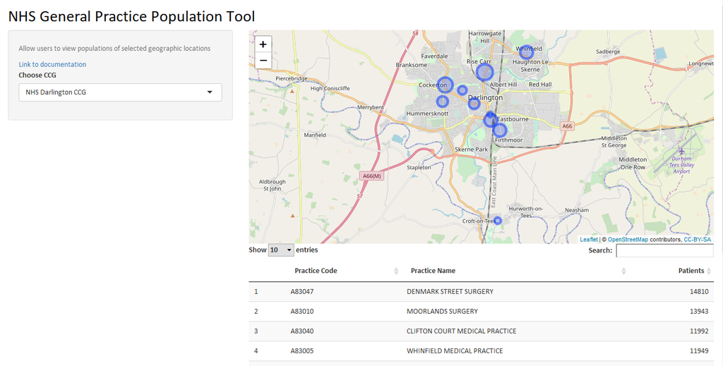